# Wie beeinflusst der Goldene Schnitt die Ziehungswahrscheinlichkeit unter zwei Fibonacci-Zahlen im Lotto 6 aus 49?

Shirin Shahidi, Matrikelnummer 455612

2019-07-24

# 1. Einleitung

> “Das, wobei unsere Berechnungen versagen, nennen wir Zufall.” - Albert Einstein (zitate.net, 2019b, o.S.).

Im deutschen Lotto 6 aus 49 lassen sich Erfolgswahrscheinlichkeiten errechnen, nicht jedoch künftige Ziehungen vorhersagen. Tendenzen, dass spezifische Ereignisse eintreten, können auf Basis bereits vergangener Ziehungen statistisch ermittelt werden (vgl. Ute Sproesser et al., 2014, S.33).

> “Etwas hat Gestalt, weil es auf Zahlen beruht[…]” (Jonak, 2018, S.136).

Die menschliche Gestaltwahrnehmung bevorzugt Vollkommenheit, Symmetrie und bestimmte Proportionen wie etwa den Goldenen Schnitt. Diese Wahrnehmungspräferenzen von Gestalten lassen sich auch im Tierreich beobachten, bei dem Gestaltwahrnehmung instinktiv zu einer Reaktion führt(vgl. Oerter, 2014, S.252).

Auf Basis dieser Tatsachen stellt sich die Frage, ob die Gestalt der Lottoziehungen bestimmte Proportionen bevorzugt oder ob Ziehungen bestimmter Zahlenkombinationen rein zufällig erfolgen. Konzentriert man sich auf die Proportion des Goldenen Schnittes, so wird dieser gemäß aktuellem Forschungsstand durch die Formel $\frac{\sqrt{5} + 1}{2}\sim1,618$ errechnet (vgl. Kohn, 2019, S.160). Leonardo of Pisa, auch unter dem Namen Fibonacci bekannt, veröffentlichte 1202 das Werk *Liber Abbaci*(vgl. Hannah, 2007, o.S.). In diesem führt er zur Fibonacci-Sequenz hin, welche im Tierreich die Vermehrung von Hasen in Zahlen beschreibt(vgl. Fibonacci, 1987, S.18). Im Lotto 6 aus 49 sind die ersten acht Fibonacci-Zahlen (1,2,3,5,8,13,21,34) enthalten(vgl. Kohn, 2019, S.159). Dividiert man zwei aufeinander folgende Fibonacci-Zahlen, so konvergieren diese gegen den Goldene Schnitt(vgl. Knebl & Springer Fachmedien Wiesbaden GmbH, 2019, S.29).

Um zur Forschungsfrage hinführen zu können, wird im Folgenden auf die beliebteste Lotterie namens Lotto 6 aus 49 unter den Einwohnern Deutschlands eingegangen(vgl. Lotto.de, 2019, o.S.). Spielberechtigt sind dabei erwachsene Personen ab 18 Jahren, da gemäß Jugendschutzgesetz § 6 Spielhallen, Glücksspiele Minderjährigen das Glücksspiel mit Chance auf hohe Geldbeträge untersagt ist(vgl. JuSchG, 2019, o.S.). Ziel eines Lottospieles ist es 6 zufällig gezogene Gewinnzahlen aus 1-49 vorgegeben Ziffern vorherzusagen. Dabei wird ein Lotto-Schein mit 12 möglichen Tippfeldern und jeweils 49 Zahlen ausgefüllt. Pro Tippfeld werden 6 Zahlen angekreuzt. Jeder Lotto-Schein enthält eine Spielscheinnummer, deren letzte Ziffer die Superzahl darstellt. Diese Superzahl wird neben den 6 Gewinnzahlen zufällig aus den Ziffern 0-9 ermittelt. Es müssen minimal 2 Ziffern und eine Superzahl korrekt prophezeit werden um einen Gewinn zu erzielen. Der maximale Gewinn stellt 6 richtige Gewinnzahlen und die korrekte Superzahl dar. Der halbierte Spieleinsatz stellt die Gewinnsumme dar, welche sich auf 9 Gewinnklassen aufteilen lässt. Zusätzlich können die Lotterien Spiel 77 und SUPER 6 sowie die GlücksSpirale im Lotto-Schein ausgewählt werden. Ein Tippfeld im Lotto 6 aus 49 kostet 1,0€ zzgl. Bearbeitungsgebühren. Die Ziehungen finden wöchentlich mittwochs um 18:25 Uhr und samstags um 19:25 Uhr unter www.lotto.de statt(vgl. Lotto.de, 2019, o.S.). Die Wahrscheinlichkeit, zwei konkrete Zahlen im Lotto zu ziehen beträgt $1:((\frac{49}{6})*(\frac{48}{5}))\sim0.01276$(vgl. Lottozahlen.com, 2019, o.S.).

## 1.1. Forschungsfrage

Betrachtet man die bereits genannten Fibonacci Zahlen im Lotto 6 aus 49 und die Konvergenz gegen den Goldenen Schnitt, lässt sich die Forschungsfrage wie folgt ableiten:

*Wie beeinflusst der Goldene Schnitt die Ziehungswahrscheinlichkeit unter zwei Fibonacci-Zahlen im Lotto 6 aus 49?*

*H1: Fibonacci-Zahlen 1,2,21 und 34 werden unter allen Fibonacci-Zahlen im Lotto 6 aus 49 am häufigsten mit ihren Goldenen Schnitt Zahlen gezogen*

In Form eines Punktschätzers kann H1 wie folgt mathematisch formuliert werden:

*H1: p1 > 0.01276*

*H2: Fibonacci-Zahlen 1,2,21, und 34 werden unter allen Fibonacci-Zahlen im Lotto 6 aus 49 am häufigsten samstags mit ihrer Goldenen Schnitt Zahl gezogen.*

*H1: p2 > 0.01276*

## 1.2. Ziel der Studie/ Analyse

Das Untersuchungsziel der Studie ist deskriptiv ausgerichtet mit der Anforderung an exakte Ergebnisse und eine repräsentative Stichprobe sowie der Beschreibung der Grundgesamtheit mit ihren wesentlichen Merkmalen.(vgl. Kuß, 2012, S.15) Ziel der Studie soll sein, herauszufinden, ob Fibonacci-Zahlenpaare, die dividiert den Goldenen Schnitt ergeben im Lotto 6 aus 49 häufiger zusammen gezogen werden als Fibonacci-Zahlenpaare ohne den Goldenen Schnitt Proportionen. Hierzu sollen nur die Gewinnzahlen ohne Superzahl in Betracht gezogen wereden, da die Superzahlziehung eine abweichende Wahrscheinlichkeit von $\frac{1}{10}$ aufweist. Es werden die Häufigkeiten der Fibonacci-Zahlen, sowie jeglicher Fibonaccipaar-Ziehungen unter allen Lotto-Ziehungen von 1955 bis Ende Juni 2019 betrachtet. Sollte sich herausstellen, dass Zahlenpaare aus dieser Auswahl am häufigsten zusammen auftreten, so werden diese mit Hilfe der Inferenzstatistik genauer betrachtet um einen Einfluss des Goldenen Schnittes auf diese Zahlenpaare ausfindig machen zu können.

# 2. Methodik

Um die Methodik festlegen zu können, wird auf das Studiendesign, sowie die Datenerhebung und die angewandten statistsichen Methoden genauer Bezug genommen (vgl. Kuß, 2012, S.13).

## 2.1. Studiendesign

Das Studiendesign wird definiert durch die Art der Datenerhebung und Ziehung der Stichprobe. Die vorliegende Studie basiert auf den Sekundärforschungen der Westdeutsche Lotterie GmbH & Co. oHG, sowie den Datenerhebungen unter www.lottozahlenonline.de durch Gustav Zygmund. (vgl. Kuß, 2012, S.15)

### 2.1.1 Datenerhebung

Da es sich um die Beschreibung der Veränderungen der Lotto-Ziehungen im Zeitablauf von 1955 bis 2019 handelt, wurden die in der Studie verwendeten Sekundärdaten in Form von Längsschnitt-Untersuchungen als Beobachtung erhoben. Da das Forschungsproblem auf Basis von Sekundärdaten bearbeitbar ist, wird in dieser Studie auf die Erhebung von Primärdaten verzichtet. Die bereits vorhandenen Daten werden für die Studie neu aufbereitet und analysiert. (vgl. Kuß, 2012, S.16)

### 2.1.2 Stichprobe

Die erhobenen Sekundärdaten stellen alle Ziehungen seit Anbeginn des Lottos 6 aus 49 von 1955 bis zum Zeitpunkt der Studienanalyse tabellarisch dar. Werden potenzielle Ungenauigkeiten wie etwa Tipp- oder Eingabefehler in den bereits vorhandenen Sekundärdaten vernachlässigt, kann von einer Totalerhebung der Daten ausgegangen werden. Dies führt dazu, dass Stichprobenfehler die Aussagekraft nicht einschränken können.(vgl. Kuß, 2012, S.43 f.)

## 2.2 Angewandte statistische Methoden

Um die Daten hinsichtlich ihrer Eignung für statistische Methoden zu überprüfen, wird eine explorative Datenanalyse zur Verdichtung der Daten durchgeführt. Da es sich um Häufigkeitsbeobachtungen der Fibonacci-Zahlenpaare in der Stichprobe handelt, werden Schätzverfahren angewandt, um Annahmen über entsprechende Wahrscheinlichkeitsverteilungen in der Grundgesamtheit treffen zu können (vgl. Kuß, 2012, S.193 f.). Eine Annahme oder Ablehnung der Hypothesen erfolgt mittels der zweiseitigen Fragestellung (vgl. Hellbrück, 2009, S.73–76). Um den Datensatz auf Linearität zu überprüfen wird anschließend eine lineare Regression durchgeführt (vgl. Hellbrück, 2009, S.250). Für die Ergebnisse der statistischen Methoden wird die Programmiersprache R mit den Bibliotheken mosaic, dplyr, knittr, gridExtra, grid, ggplot2, lattice und citr verwendet. Diese ermöglicht den Einsatz moderner Verfahren der Datenanalyse und ist reproduzierbar, automatisierbar, quelloffen, kostenlos und grafisch abbildbar. (vgl. Sauer, 2018, S.16 f.) Für den Datensatz wurden die Ereignisse der Lotto-Ziehungen aus den Quellen Westdeutsche Lotterie GmbH & Co. oHG sowie den Beobachtungen durch Gustav Zygmund in einem Datensatz zusammengeführt und auf die Gewinnzahlen, sowie den Wochentag reduziert. Diese Datenaufbereitung fand manuell mittles dem Office Programm Excel statt.

# 3. Ergebnisse

Um zu den Ergebnissen der Studie hinführen zu können werden die bereits genannten statistischen Methoden im Folgenden anhand von R-Syntax-Abschnitten (sogenannten Chunks) erklärt, sowie grafisch veranschaulicht (vgl. Sauer, 2018, S.26).

## 3.1 Kennzahlen der Stichprobe

Um einen Überblick über die Kennzahlen der Stichprobe zu erhalten, wird die Bibliothek “mosaic” geladen und der R-Befehl “inspect” ausgeführt:

```
##
## categorical variables:
##        name  class levels    n missing
## 1 Wochentag factor      6 4295       0
##                                    distribution
## 1 Samstag (65.3%), Mittwoch (22.6%) ...
##
## quantitative variables:
##        name   class min Q1 median Q3 max     mean       sd    n missing
## 1 GewZahl_1 integer   1 12     25 37  49 24.64331 14.31717 4295       0
## 2 GewZahl_2 integer   1 12     24 37  49 24.64983 14.25556 4295       0
## 3 GewZahl_3 integer   1 13     25 37  49 25.11665 13.86886 4295       0
## 4 GewZahl_4 integer   1 13     25 37  49 25.06682 13.98750 4295       0
## 5 GewZahl_5 integer   1 13     26 38  49 25.45285 14.06999 4295       0
## 6 GewZahl_6 integer   1 13     26 38  49 25.46123 14.44079 4295       0
```

Die Stichprobe des Datensatzes Lotto 6 aus 49 von 1955 bis 2019 enthält 6 numerisch diskrete und eine kategoriale Variable. Insgesamt enthält die Stichprobe 4295 Beobachtungen. Die numerischen Variablen stellen die Gewinnzahlen kategorisiert nach Ziehungsrunde dar. Das Minimum liegt bei der Ziffer 1 und das Maximum bei Ziffer 49. Die kategoriale Variable nennt den Wochentag, an dem die Beobachtungen aufgezeichnet wurden. Die Lagemaße und Streumaße sind unterschiedlich ausgeprägt, wie anhand der Werte von Quantil 1 und 3 sowie der Mittelwerte und dem Median zu erkennen ist. Die Standardabweichung fällt ebenfalls unterschiedlich aus. Die Variablennamen werden wie folgt ausgegeben: GewZahl_1, GewZahl_2, GewZahl_3, GewZahl_4, GewZahl_5, GewZahl_6, Wochentag. Insgesamt sind keine fehlenden Angaben vorhanden. Einen Überblick über die letzten 6 Beobachtungen des Datensatzes verschafft der Befehl “tail”:

|  | GewZahl_1 | GewZahl_2 | GewZahl_3 | GewZahl_4 | GewZahl_5 | GewZahl_6 | Wochentag |
| --- | --- | --- | --- | --- | --- | --- | --- |
| 4290 | 3 | 11 | 15 | 18 | 33 | 45 | Samstag |
| 4291 | 3 | 13 | 25 | 27 | 32 | 48 | Mittwoch |
| 4292 | 5 | 6 | 14 | 16 | 31 | 48 | Samstag |
| 4293 | 3 | 22 | 24 | 25 | 43 | 45 | Mittwoch |
| 4294 | 5 | 14 | 32 | 37 | 46 | 47 | Samstag |
| 4295 | 10 | 15 | 31 | 34 | 35 | 45 | Mittwoch |

## 3.2 explorative Statistik

Anhand der explorativen Statistik sollen Häufigkeitsverteilungen der Fibonacci-Zahlen betrachtet werden. Hierzu wird der Datensatz nach Fibonacci-Zahlen mittels R-Skript (“_01_Sort_by_Fibo.R“) sortiert und gefiltert. Die daraus gewonnen Daten werden auf Fibonacci-Zahlenpaare im Goldenen Schnitt Verhältnis und deren Häufigkeitsverteilung überprüft und nach Häufigkeit der Ziehung betrachtet. Dadurch zeigt sich, welche Fibonacci-Zahlen mit welchen Fibonacci-Zahlen am häufigsten gemeinsam in einer Ziehung auftreten (siehe Tabelle 1).

Die Tabelle zeigt zeilenweise, welche Fibonacci-Zahlen im Lotto 6 aus 49 seit 1955 bis 2019 mit welchen Fibonacci-Zahlen wie häufig (in Ziehungen) gemeinsam gezogen wurden. Die häufigsten Beobachtungen wurden fett markiert. Es wird ersichtlich, dass die 1, 2, 21 und 34 am häufigsten mit ihren Goldenen Schnitt Zahlen gezogen wurden.

|  | Fibonacci Zahl 1 | Fibonacci Zahl 2 | Fibonacci Zahl 3 | Fibonacci Zahl 5 | Fibonacci Zahl 8 | Fibonacci Zahl 13 | Fibonacci Zahl 21 | Fibonacci Zahl 34 |
| --- | --- | --- | --- | --- | --- | --- | --- | --- |
| Fibonacci Zahl 1 |  | **59** | 57 | 54 | 47 | 44 | 56 | 45 |
| Fibonacci Zahl 2 | **59** |  | 55 | 53 | 57 | 42 | 54 | 58 |
| Fibonacci Zahl 3 | 57 | 55 |  | 52 | 48 | 56 | **57** | 49 |
| Fibonacci Zahl 5 | 54 | 53 | 52 |  | 55 | **57** | 54 | 45 |
| Fibonacci Zahl 8 | 47 | 57 | 48 | 55 |  | 38 | 41 | **57** |
| Fibonacci Zahl 13 | 44 | 42 | 56 | **57** | 38 |  | 56 | 47 |
| Fibonacci Zahl 21 | 56 | 54 | 57 | 54 | 41 | 56 |  | **63** |
| Fibonacci Zahl 34 | 45 | 58 | 49 | 45 | 57 | 47 | **63** |  |

Aus Tabelle 1 ergibt sich die erste Hypothese: Die Fibonacci-Zahlen 1, 2, 21 und 34 werden unter allen Fibonacci-Zahlen im Lotto 6 aus 49 am häufigsten mit ihren Goldenen Schnitt Zahlen gezogen.

Die Verteilung der Wochentage im Lotto lässt sich anhand Abbildung 1 veranschaulichen. Betrachtet man die Häufigkeitsverteilung der Fibonacci-Zahlenpaare 1&2 sowie 21&34 hinsichtlich der Wochentage ergibt sich Abbildung 2.

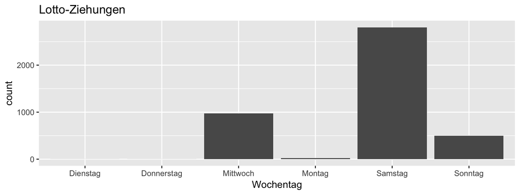

Die Lotto-Ziehungen von 1955 bis 2019 fanden am häufigsten samstags statt.

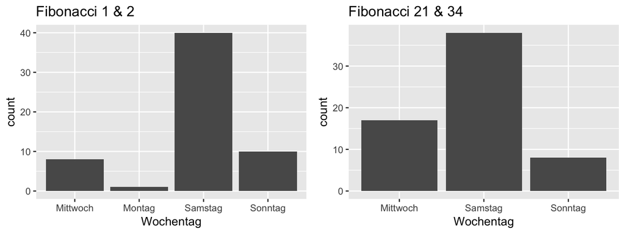

Die Fibonacci Zahlen 1, 2, 21 und 34 werden samstags am häufigsten mit ihren Goldenen Schnitt Zahlen gezogen.

Die Häufigkeitsverteilungen können tabellarisch festgehalten werden.

Die Samstagsziehungen machen ca. 65% der Lottoziehungen aus. Das Fibonacci Zahlenpaar 21&34 wird um 4 zusätzliche Ziehungen häufiger als das Zahlenpaar 1&2 gezogen. Samstags wird das Zahlenpaar 1&2 um 2 Ziehugen häufiger als das Zahlenpaar 21&34 gezogen. Fibonacci-Zahlenpaare im Goldenen Schnitt werden mit <1,5% relativ selten im Lotto 6 aus 49 gezogen.

| Ereignis | absolute Häufigkeit (Ziehungsanzahl) | relative Häufigkeit (in %) |
| --- | --- | --- |
| Samstagziehungen Gesamt | 2805 | 65.3085 % |
| Fibonacci Zahlenpaar 1&2 | 59 | 1.37369 % |
| Fibonacci Zahlenpaar 21&34 | 63 | 1.466822 % |
| Samstagziehungen Fibonacci Zahlenpaar 1&2 | 40 | 1.426025 % |
| Samstagziehungen Fibonacci Zahlenpaar 21&34 | 38 | 1.354724 % |

Aus diesen Beobachtungen lässt sich die Hyothese ableiten, dass die Fibonacci Zahlen 1,2,21 und 34 samstags am häufigsten mit ihren Goldenen Schnitt Zahlen gezogen werden.

## 3.3 deskriptive Statistik

Die deskriptive Statistik beschäftig sich mit den Lage- und Streuparametern des Datensatzes. Die Lagemaße spiegeln die Verteiung der Daten wieder, wohingegen die Streuungsmaße die Unterschiedlichkeiten in den Daten wiedergeben. (vgl. Sauer, 2018, S.104–105) Die Lagemaße der Fibonacci Zahlenpaare 1&2 werden durch folgenden Boxplot gekennzeichnet (siehe Abbildung 3).

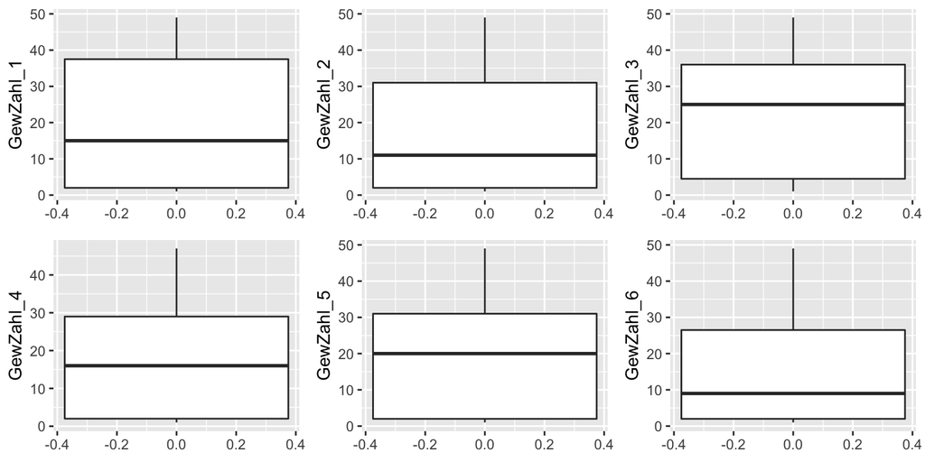

Betrachtet man die Reihenfolge der gezogenen Zahlen bei den Ziehungen der Fbonacci Zahlen 1&2, so lässt sich veranschaulichen, dass die Werte je nach Ziehungsrunde variieren. Die unteren 25% enthalten dabei immer (bis auf die dritte Gewinnzahl) die Ziffern 1 und 2.

Die Mittelwerte, der Gewinnzahlen der Fibonacci Zahlenpaare 1&2 werden in Tabelle 3 dargestellt.

Die Gewinnzahlen der Fibonacci-Ziehungspaare 1&2 unterscheiden sich in ihren Mittelwerten. Gewinnzahl 3 weist den größten Mittelwert mit 22.08475 auf, Gewinnzahl 6 den niedrigsten mit 15.69492.

| Gewinnzahl | Mittelwert |
| --- | --- |
| Gewinnzahl 1 | 19.20339 |
| Gewinnzahl 2 | 16.89831 |
| Gewinnzahl 3 | 22.08475 |
| Gewinnzahl 4 | 17.83051 |
| Gewinnzahl 5 | 17.94915 |
| Gewinnzahl 6 | 15.69492 |

Die Lagemaße der Fibonacci-Zahlen 21&34 werden durch die Abbildung 4 dargestellt.

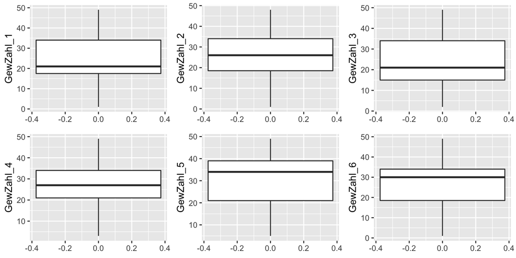

Die Mittelwerte, der Gewinnzahlen der Fibonacci Zahlenpaare 21&34 werden in Tabelle 4 dargestellt.

Die Gewinnzahlen der Fibonacci-Ziehungspaare 21&34 unterscheiden sich in ihren Mittelwerten. Gewinnzahl 5 weist den größten Mittelwert mit 29.77778 auf, Gewinnzahl 3 den niedrigsten mit 24.01587.

| Gewinnzahl | Mittelwert |
| --- | --- |
| Gewinnzahl 1 | 24.95238 |
| Gewinnzahl 2 | 25.55556 |
| Gewinnzahl 3 | 24.01587 |
| Gewinnzahl 4 | 27.39683 |
| Gewinnzahl 5 | 29.77778 |
| Gewinnzahl 6 | 26.42857 |

Zur Bestimmung des Modus der Gewinnzahlen aus den Fibonacci-Zahlenpaaren 1&2 kann folgende Tabelle dargestellt werden.(siehe Tabelle 5)

Die Modi der Gewinnzahlen der Fibonacci-Ziehungspaare 1&2 unterscheiden sich in ihren Ziehungshäufigkeiten. Es wird ersichtlich, dass die Ziffern 1 und 2 in jeder Ziehung am häufigsten auftreten.

| Gewinnzahl | Am häufigsten gezogene Zahl | Anzahl der Ziehungen |
| --- | --- | --- |
| Gewinnzahl 1 | 2 | 12x |
| Gewinnzahl 2 | 1&2 | je 11x |
| Gewinnzahl 3 | 1&2 | je 7x |
| Gewinnzahl 4 | 2 | 11x |
| Gewinnzahl 5 | 1 | 13x |
| Gewinnzahl 6 | 1 | 11x |

Zur Bestimmung des Modus der Gewinnzahlen aus den Fibonacci-Zahlenpaaren 21&34 kann folgende Tabelle dargestellt werden.(siehe Tabelle 6)

| Gewinnzahl | Am häufigsten gezogene Zahl | Anzahl der Ziehungen |
| --- | --- | --- |
| Gewinnzahl 1 | 21 | 15x |
| Gewinnzahl 2 | 34 | 12x |
| Gewinnzahl 3 | 21 | 11x |
| Gewinnzahl 4 | 34 | 11x |
| Gewinnzahl 5 | 34 | 9x |
| Gewinnzahl 6 | 34 | 14x |

Um zu prüfen, ob die Gewinnzahlen der Fibonacci-Zahlenpaare 1&2 korrelieren wird vorab eine grafische Übersicht mittels des R-Befehls “gf_point” angewandt um Tendeznen des Zusammenhangs zu erkennen.

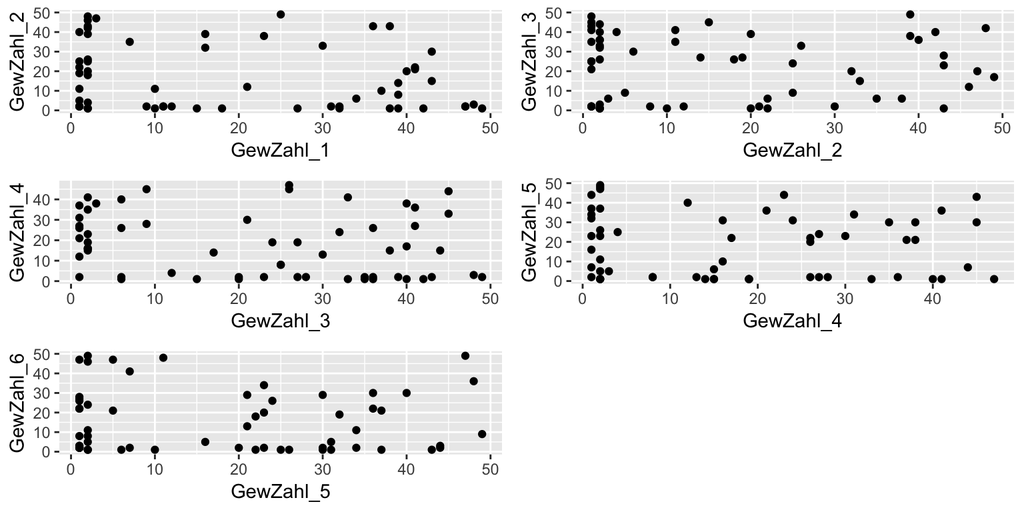

| Unabhängige Variable | Abhängige Variable | Korrelationskoeffizient |
| --- | --- | --- |
| Gewinnzahl 1 | Gewinnzahl 2 | -0.21260081 |
| Gewinnzahl 2 | Gewinnzahl 3 | -0.03212074 |
| Gewinnzahl 3 | Gewinnzahl 4 | -0.2106801 |
| Gewinnzahl 4 | Gewinnzahl 5 | -0.07762 |
| Gewinnzahl 5 | Gewinnzahl 6 | -0.05135401 |

## 3.4 Inferenzstatistik

Da sich die bisherige Datenanlyse auf eine einzige Stichprobe bezieht, ist fraglich, wie aussagekräftig die Stichprobe für das Verhalten der Fibonacci-Zahlen im Goldenen Schnitt Verhältnis im Lotto 6 aus 49 ist. (vgl. Sauer, 2018, S.268) Mittels der simualtionsbasierten Inferenz und dem Resampling ist es möglich, die Genauigkeit des geschätzten Wertes mittels Bootstrapping und einem Konfidenzintervall zu quantifizieren.(vgl. Sauer, 2018, S.310) Zum Testen der Hypothesen wird die Nullhypothese durch den hypothetischen Wert (siehe Einleitung) sowie durch das Resamplingverfahren mittels Permutation abgebildet. (vgl. Siebertz, Bebber & Hochkirchen, 2017, S.384) Mittels linearen Regression soll anschließen überprüft werden, ob Werte mittels einer Geraden prophezeit werden können.(vgl. Sauer, 2018, S.322)

### 3.4.1 Bootstrap

Um die Hypothese prüfen zu können wird im ersten Schritt aus der bereits vorhanden Stichprobe eine Stichprobenverteilung vom Umfang n = 10.000 Stichproben erstellt. Hierzu wird mittels R-Skript “_03_Bootstrap_Lotto_Gesamt.R" die vorhandene Stichprobe mit 4295 Ziehungen mit Zurücklegen zufällig neu gezogen. Die neu gezogene Stichprobe wird danach auf die Häufigkeitsverteilung der Fibonacci-Zahlenpaare 1&2 sowie 21&34 untersucht. Dieser Vorgang wird 10.000 Mal wiederholt. Dabei werden auch die Wochentage berücksichtigt. In Form von Balkendiagrammen werden die Verteilungshäufigkeiten grafisch dargestellt.

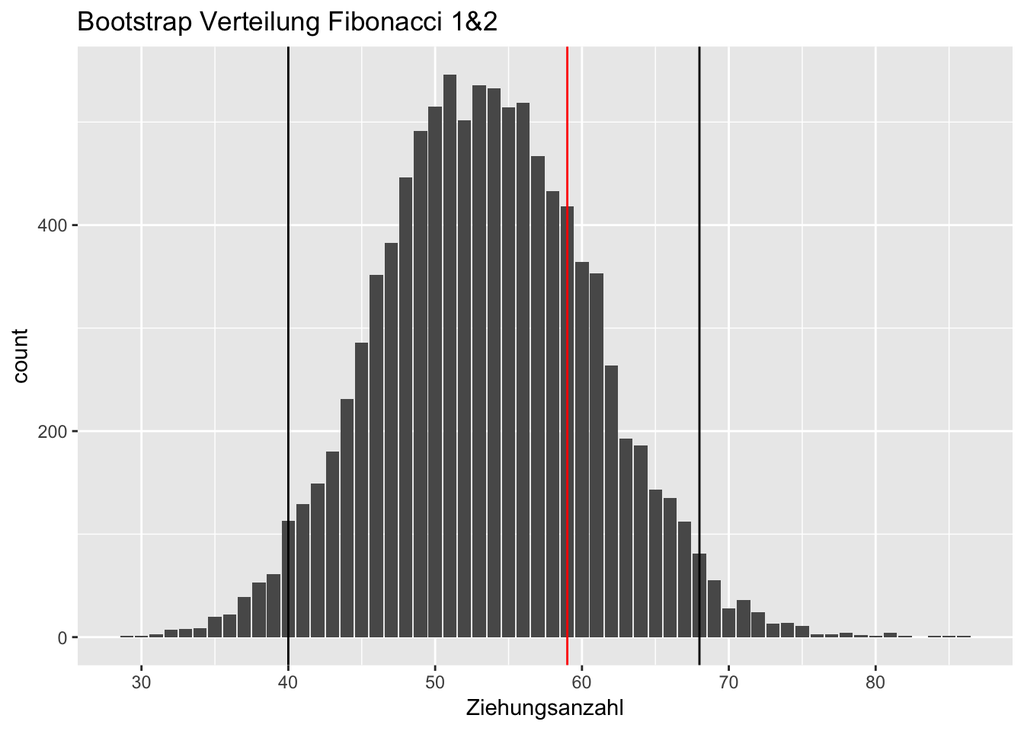

In 25% der Stichprobenverteilungen des Bootstrap Resamplings wurden die Fibonacci-Zahlen 1&2 40 Mal gezogen und in 75% der Stichprobenverteilungen 68 Mal (schwarze Linien). Der p-Wert der Originalstichprobe weist eine Ziehungsanzahl von 59 auf (rote Linie). Dieser Wert liegt noch innerhalb der Quantile und stellt somit einen plausiblen Wert dar. Die Nullhypothese wird zum Signifikanzniveau von 95% angenommen.

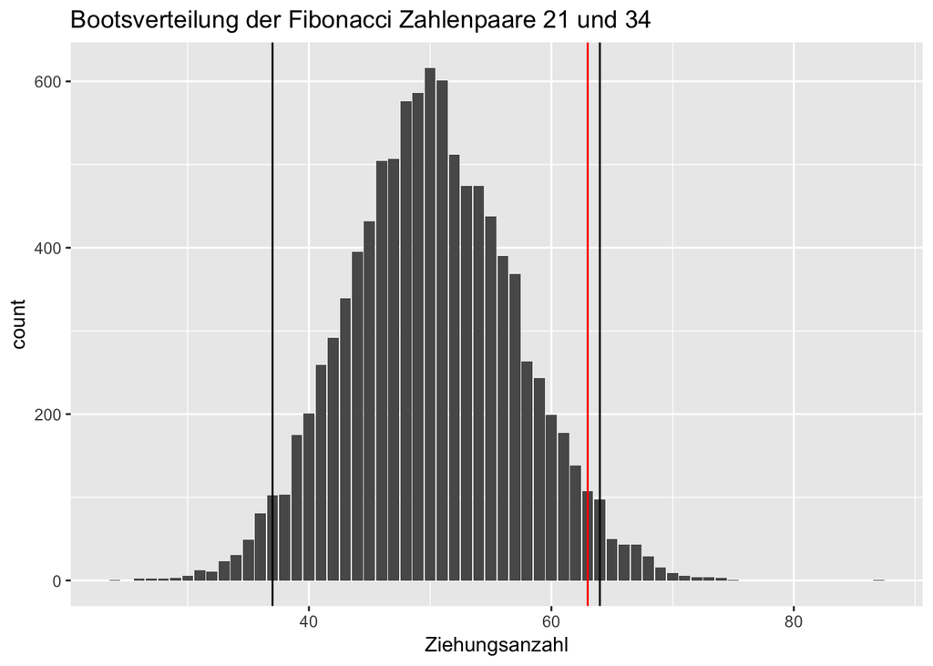

In 25% der Stichprobenverteilungen des Bootstrap Resamplings wurden die Fibonacci-Zahlen 21&34 37 Mal gezogen und in 75% der Stichprobenverteilungen 64 Mal (schwarze Linien). Der p-Wert der Originalstichprobe weist eine Ziehungsanzahl von 63 auf (rote Linie) Dieser Wert liegt noch innerhalb der Quantile und stellt somit einen plausiblen Wert dar. Die Nullhypothese wird zum Signifikanzniveau von 95% angenommen.

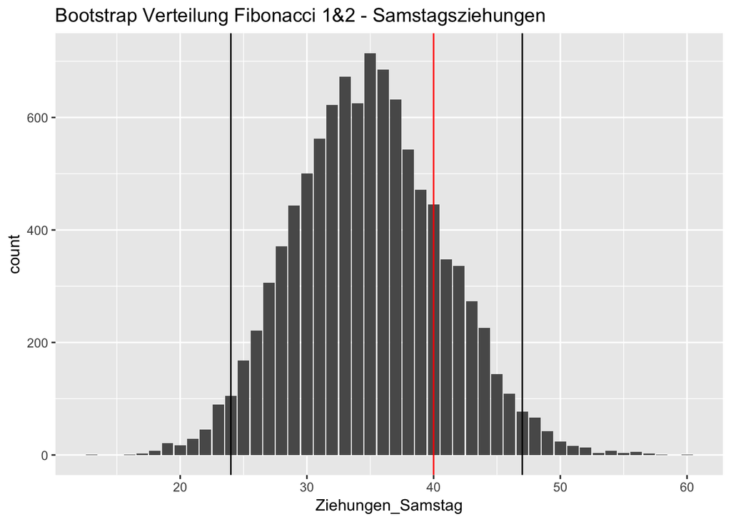

In 25% der Stichprobenverteilungen des Bootstrap Resamplings wurden die Fibonacci-Zahlen 1&2 samstags 24 Mal und in 75% der Stichprobenverteilungen 47 Mal gezogen (schwarze Linien). Der p-Wert der Originalstichprobe weist eine Ziehungsanzahl von 40 Samstagsziehungen auf (rote Linie). Dieser Wert liegt innerhalb der Quantile und stellt somit einen plausiblen Wert dar. Die Nullhypothese wird zum Signifikanzniveau von 95% angenommen.

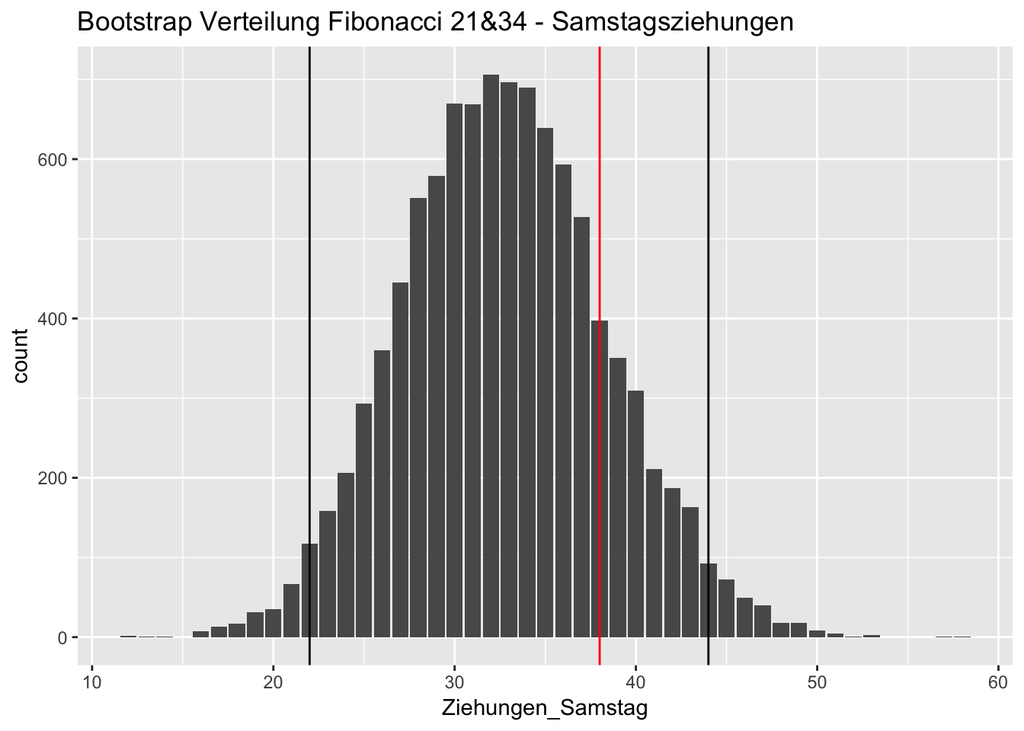

In 25% der Stichprobenverteilungen des Bootstrap Resamplings wurden die Fibonacci-Zahlen 21 und 34 samstags 22 Mal und in 75% der Stichprobenverteilungen 44 Mal gezogen (schwarze Linien). Der p-Wert der Originalstichprobe weist eine Ziehungsanzahl von 38 Samstagsziehungen auf (rote Linie). Dieser Wert liegt noch innerhalb der Quantile und stellt somit einen plausiblen Wert dar. Die Nullhypothese wird zum Signifikanzniveau von 95% angenommen.

Aus den Grafiken geht hervor, dass sowohl H1 als auch H2 verworfen werden können.

### 3.4.2 Permutation

Mittels der Permutation wird die Nullhypothese simuliert. Hierzu werden zufällig 6 Ziffern aus den vorgegebenen Ziffern 1-49 ohne Zurücklegen gezogen. Die Wochentage werden ebenso ohne Effekt zufällig ohne Zurücklegen gezogen. Der hypothetische Wert wird ebenso in einem zweiten Schritt zu Hypothesentestung verwendet.

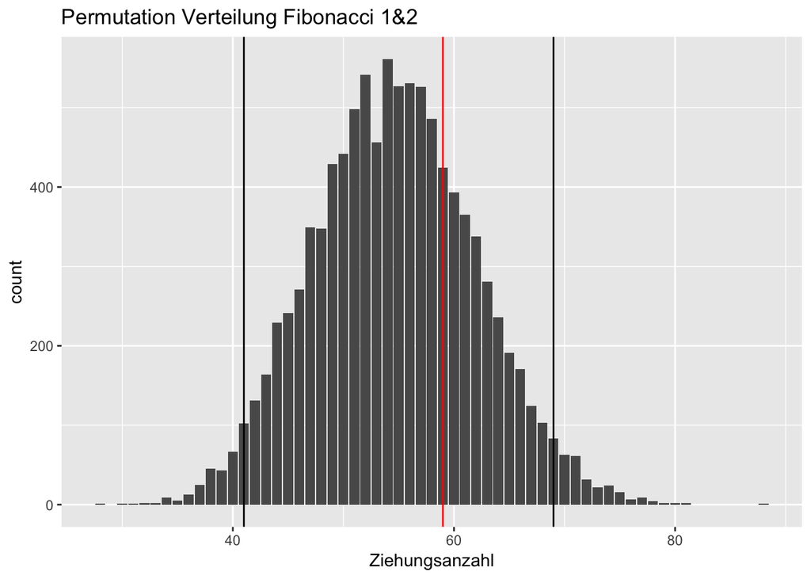

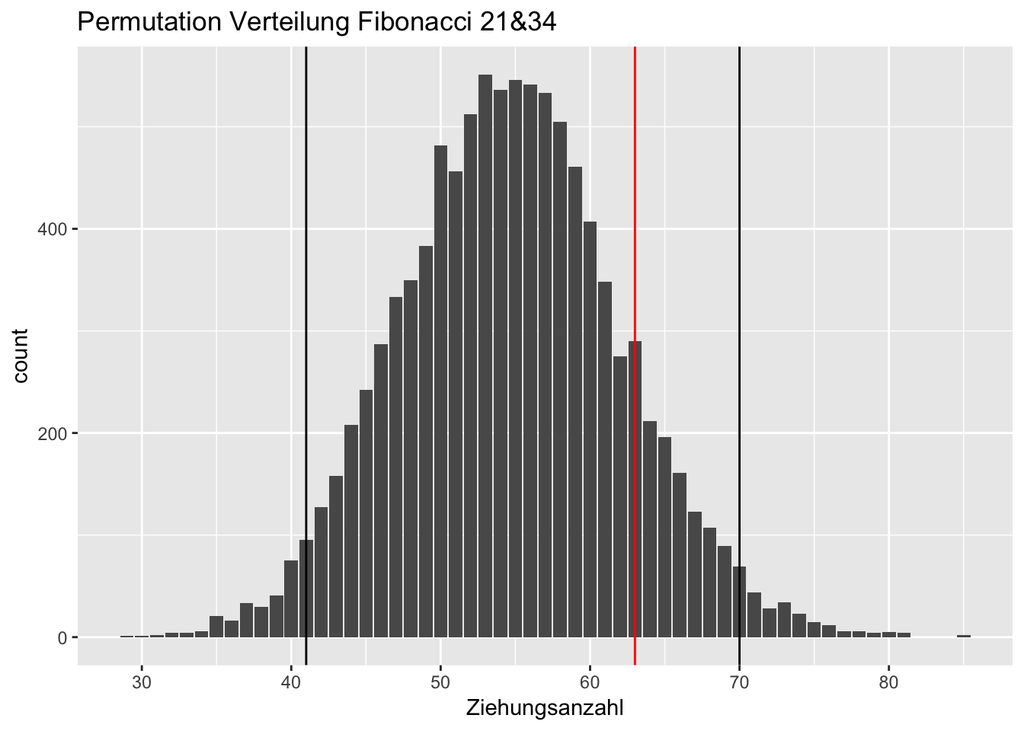

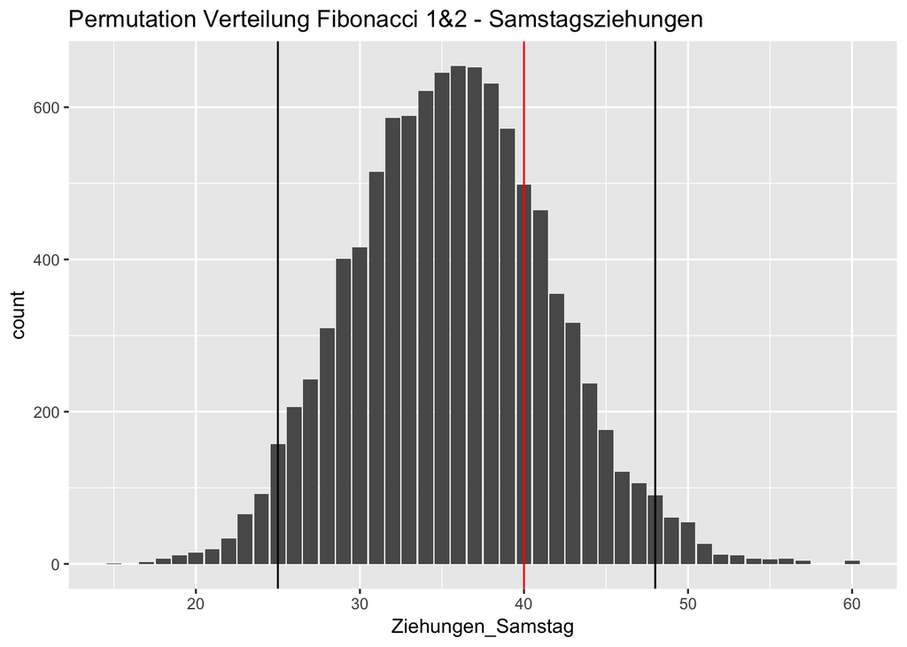

[figure not shown]

### 3.4.3 Lineare Regression

Anhand der linearen Regression kann erklärt werden, dass die Gewinnzahlen nicht durch die vorherige Gewinnzahl erklärt werden kann. Weder in der selektierten Liste, noch im Gesamtlotto.

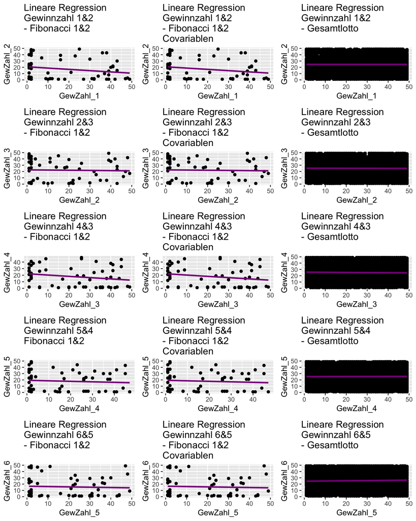

Lineares Modell zeigt, dass keine Erklärung einer Gewinnzahl durch ihre vorherige Gewinnzahl erfolgt. Die Regressionsgerade verläuft im Gesamtlotto-Modell horizontal. In der nach Fibonaccizahlen 1&2 sortierten Ansicht verläuft die Gerade mit geringer negativer Steigung. Dies wird bedingt durch die geringe Anzahl an Ziehungen. Hinsichtlich der Streuung kann kein Zusammenhang erklärt werden und keine Vorhersage über den Verlauf der Gewinnzahlen getroffen werden. Die Covariablen der Gewinnzahlen haben keinen Einfluss auf den R-squared Wert, da auch hier die Regressionsgerade annähernd horizontal verläuft.

Für die Gewinnzahlen 21 und 34 wird ebenfalls ein lineares Modell erstellt. Aus diesem geht hervor, dass kein linearer Zusammenhang der Gewinnzahlen besteht.

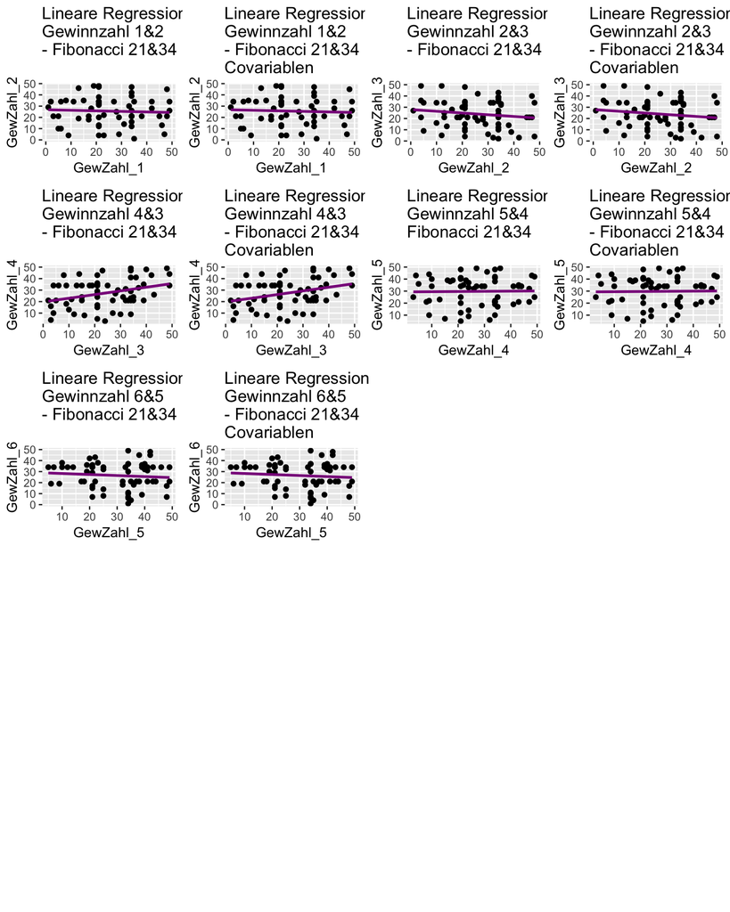

Die linearen Geraden zeigen kaum einen linearen Zusammenhang, da diese relativ horizontal verlaufen. Lediglich die Gewinnzahlen 3 und 4 zeigen eine positive Steigung der Geraden auf. Die Covariablen der Gewinnzahlen haben keinen Einfluss auf den R-squared Wert, da auch hier die Regressionsgerade annähernd horizontal verläuft. Es ist kein linearer Zusammenhang der Gewinnzahlen in den Fibonaccizahlenpaaren 21 nd 34 zu erkennen.

Es ist zu diskutieren, in wie weit die abweichenden Steigungen der Geraden in den beschriebenen Gewinnzahlen aussagekräftig sind. Hierzu werden im Folgenden zwei Tabellen mit den R-squared Werten, sowie den entsprechenden p-Werten aufgezeigt, unterteilt in die Fibonacci-Zahlenpaare 1&2 sowie 21&34.

Dargestellt sind die Bestimmtheitsmaße und p-Werte der Fibonacci-Zahlenpaare 1&2. Die Bestimmtheitsmaße (multiple als auch adjusted) weisen niedrige Werte auf, sodass nur schwache Effekte zwischen den Gewinnzahlen erkennbar sind. Hohe p-Werte bestätigen diese Tatsache. Die Gewinnzahlen in den Ziehungen mit den Fibonaccizahlenpaaren 1 und 2 lassen sich somit nicht durch ihre vorherigen Gewinnzahlen erklären.

| Unabhängige Variable | Abhängige Variable | Multiple R-squared | Adjusted R-squared | p-Wert |
| --- | --- | --- | --- | --- |
| Gewinnzahl 1 | Gewinnzahl 2 | 0.0452 | 0.02845 | 0.106 |
| Gewinnzahl 2 | Gewinnzahl 3 | 0.001032 | -0.01649 | 0.8092 |
| Gewinnzahl 3 | Gewinnzahl 4 | 0.04439 | 0.02762 | 0.1092 |
| Gewinnzahl 4 | Gewinnzahl 5 | 0.006025 | -0.01141 | 0.559 |
| Gewinnzahl 5 | Gewinnzahl 6 | 0.002637 | -0.01486 | 0.6993 |

[output not shown]

Aus den Grafiken und Tabellen zeigt das Ergebnis, dass die Gewinnzahlen in keinem Zusammenhang zu ihren vorherigen Gewinnzahlen stehen.

# 4. Diskussion

| Fibonacci-Zahlenpaare | p-Wert Stichprobe | p-Wert Bootstrap | p-Wert Permutation | hypothetischer Wert |
| --- | --- | --- | --- | --- |
| 1&2 | ~0.01374 | ~0.01187 | ~0.01257 | 0.01276 |
| 21&34 | ~0.01467 | ~0.01164 | ~0.01234 | 0.01276 |

Betrachtet man die Ergebnisse im Kontext zu bereits publizierter Literatur, zeigt sich, dass die Fibonacci Zahlen auch in Wettsystemen häufig Einsatz finden.(vgl. Mr Green, 2019, o.S.) Dass die Fibonacci Zahlen mit ihrem Goldene Schnitt keinen Einfluss im Wettsystem haben, untermauert die Ergebnisse der analysierten Studie. (vgl. Pinnacle, 2019, o.S.) Im Fibonacci-Roulette System beispielsweise können Fibonacci-Zahlen zwar zum Erfolg führen, dies unterliegt jedoch ebenso dem Zufall. (vgl. Banks, 2014, o.S.)

# 5. Schlussfolgerungen

“Es steckt oft mehr Geist und Scharfsinn in einem Irrtum als in einer Entdeckung.” - Joseph Joubert (zitate.net, 2019a, o.S.)

Der Goldene Schnitt hat auf Basis dieser Studie keinen Einfluss auf die Ziehungswahrscheinlichkeit unter zwei Fibonacci-Zahlen im Lotto 6 aus 49. Die Studie spiegelt demnach wieder, dass es sich im Lotto 6 aus 49 um ein Glücksspiel handelt, dessen Ereignisse trotz umfangreicher Analyse nicht prophezeit werden können. Der Goldene Schnitt vermag in der Architektur, dem Tierreich und der Natur ein Phänomen darstellen, nicht jedoch in der beliebtesten Lotterie der Deutschen.(vgl. WhiteWall, 2019, o.S.) Trotz umfangreicher Stichprobe findet die Datensatzanalyse ihre Grenzen im Bereich des Glücksspieles - speziell der Lotterie in Deutschland. Hier können Ergebnisse nur auf das Glücksspiel Lotto 6 aus 49 übertragen werden und nicht allgemein für Lotterien in Deutschland. Auch wurden in der Studie die Superzahlen nicht berücksichtig. Diese Merkmalsausprägungen wären für künftige Studien interessant und könnten die Forschungslücke schmälern. Eine Betrachtung des Verhaltens der Fibonacci-Zahlen im Goldenen-Schnitt Verhältnis im EuroJackpot wären für künstige Datenanalysen denkbar.

# Literaturverzeichnis

Banks, G. (2014) *Fibonacci Roulette System. Roulette Ratgeber*. [Online]. 24 Dezember 2014. Available from: http://www.rouletteratgeber.info/fibonacci-roulette-system.html [Zugegriffen: 24 Juli 2019].

Fibonacci, L.P. (1987) INTRODUCTION: A Brief Biography of Leonardo Pisano (Fibonacci) [1170-post 1240]. In: LEONARDO PISANO Fibonacci (Hrsg.). *The Book of Squares*. [Online]. San Diego, Academic Press. S. xv–xx. Available from: doi:10.1016/B978-0-08-088650-3.50005-0 [Zugegriffen: 15 Juli 2019].

Hannah, J. (2007) False position in Leonardo of Pisa’s Liber Abbaci. *Historia Mathematica*. [Online] 34 (3), 306–332. Available from: doi:10.1016/j.hm.2006.10.004 [Zugegriffen: 15 Juli 2019].

Hellbrück, R.P. (2009) OCLC: 458747755. *Angewandte Statistik mit R: eine Einführung für Ökonomen und Sozialwissenschaftler*. Lehrbuch. 1. Aufl. Wiesbaden, Gabler.

Jonak, U. (2018) *Essays zur Architektur*. [Online]. Wiesbaden, Springer Fachmedien Wiesbaden. Available from: doi:10.1007/978-3-658-19129-0 [Zugegriffen: 8 Juli 2019].

JuSchG (2019) *JuSchG - Jugendschutzgesetz*. [Online]. 2019. Available from: https://www.gesetze-im-internet.de/juschg/BJNR273000002.html [Zugegriffen: 16 Juli 2019].

Knebl, H. & Springer Fachmedien Wiesbaden GmbH (2019) OCLC: 1098316960. *Algorithmen und Datenstrukturen Grundlagen und probabilistische Methoden für den Entwurf und die Analyse*.

Kohn, W. (2019) OCLC: 1102475595. *MATHEMATIK FR WIRTSCHAFTSINFORMATIKER: grundlagen und anwendungen.* S.l., SPRINGER.

Kuß, A. (2012) OCLC: 795116334. *Marktforschung: Grundlagen der Datenerhebung und Datenanalyse*. Springer-Gabler-Lehrbuch. 4., überarb. Aufl. Wiesbaden, Springer Gabler.

Lotto.de (2019) *LOTTO 6aus49 Spielregeln LOTTO.de*. [Online]. 2019. Available from: https://www.lotto.de/lotto-6aus49/spielregeln [Zugegriffen: 16 Juli 2019].

Lottozahlen.com (2019) *6 aus 49 Wahrscheinlichkeit einfach erklärt. Lottozahlen*. [Online]. 2019. Available from: https://www.lottozahlen.com/lotto-nachrichten/6-aus-49-wahrscheinlichkeit-einfach-erklaert [Zugegriffen: 16 Juli 2019].

Mr Green (2019) *Das Fibonacci Wettsystem schnell erklärt Mr Green Sportsbook DE. Mr Green*. [Online]. 2019. Available from: https://www.mrgreen.com/de/sportwetten/strategien/fibonacci [Zugegriffen: 24 Juli 2019].

Oerter, R. (2014) OCLC: 887522626. *Der Mensch, das wundersame Wesen: was Evolution, Kultur und Ontogenese aus uns machen*. Wiesbaden, Springer Spektrum.

Pinnacle (2019) *Eine Untersuchung des Fibonacci-Wettsystems. Pinnacle*. [Online]. 2019. Available from: http://www.pinnacle.com/de/betting-articles/Betting-Strategy/What-is-the-Fibonacci-betting-system/47LJRM4KLKLUZXKX [Zugegriffen: 24 Juli 2019].

Sauer, S. (2018) *Moderne Datenanalyse mit R: Daten einlesen, aufbereiten, visualisieren und modellieren*. FOM-Edition. 1. Auflage 2019. Wiesbaden, Springer Fachmedien Wiesbaden GmbH.

Siebertz, K., Bebber, D. van & Hochkirchen, T. (2017) OCLC: 1007269389. *Statistische Versuchsplanung: Design of Experiments (DoE)*. VDI-Buch. 2. Auflage. Berlin, Springer Vieweg.

Ute Sproesser et al. (2014) *Daten, Zufall und der Rest der Welt: didaktische Perspektiven zur anwendungsbezogenen Mathematik*. Research. Silvia Wessolowski & Claudia Wörn (Hrsg.). Wiesbaden, Springer Spektrum.

WhiteWall (2019) *Der Goldene Schnitt - Inspirationen für die Bildgestaltung. WhiteWall*. [Online]. 2019. Available from: https://www.whitewall.com/de/mag/goldener-schnitt [Zugegriffen: 24 Juli 2019].

zitate.net (2019a) *Joseph Joubert Zitate und Sprüche ... Zitate.net*. [Online]. 2019. Available from: http://zitate.net/joseph-joubert-zitate?p=2 [Zugegriffen: 14 Juli 2019].

zitate.net (2019b) *Zufallzitate Top 20 Zitate und Sprüche über Zufälle ... Zitate.net*. [Online]. 2019. Available from: http://zitate.net/zufall-zitate [Zugegriffen: 14 Juli 2019].